# Chapter 6 - Handling and Pre-processing Sequencing Data

Sasha Ajay Malkani

2025-12-26

## 1. Handling and Pre-processing Sequencing Data

This chapter provides a comprehensive overview of managing various types of sequencing data, specifically focusing on the capabilities of R, a powerful and versatile programming language for statistical computing. We will explore the foundational concepts, packages, and best practices in pre-processing sequencing data, ensuring that you are equipped to conduct a robust analysis in your biological studies.

### 1. A. Understanding Sequencing Data

Sequencing data can come in several forms, such as:

- **Raw Reads**: The raw output from a sequencing machine, typically in FASTQ format.
- **Aligned Reads**: Processed reads that have been aligned to a reference # genome (e.g., in BAM format).
- **Count Data**: Summarized data representing the number of reads mapped to specific features, such as genes (e.g., in a count table format).

Understanding the structure and format of your data is essential before diving into pre-processing steps.

### 1. B. R and Sequencing Data Formats

R can hamdle various sequencing data formats through specific packages. Notable formats include:

- **FASTQ**: contains raw reads along with their quality scores.
- **BAM/SAM**: Binary and text formats for storing aligned reads.
- **VCF**: A format for displaying SNPs and indels.
- **Count Table**: A matrix of counts for genes or features across samples.

Packages such as “short Read”, “Genomic Ranges”, “Rsamtools”, and “DESeq2” facilitate the management and conversion of these files.

#### 1. B. I. Loading FASTQ Files

```r
# Install "ShortRead" Package
# BiocManager::install(c("ShortRead"), type = "source", force = TRUE)

# Update co-dependent BioConductor packages
# BiocManager::install(c("SparseArray", 'GenomicRanges', 'S4Arrays', "rtracklayer"),
# type = "source", force = TRUE)

# Load "Short Read" Package
library(ShortRead)
# Define the file path
fastq_file <- "D:/Ajay Files/R Programming for Bioinformatics/Chapter 6/wu_0_A_wgs.fastq"

# Load the FASTQ file
fastq_data <- readFastq(fastq_file)

# Inspect the first few reads
head(fastq_data)
```

```
## class: ShortReadQ
## length: 6 reads; width: 36 51 cycles
```

### 1. C. Quality Control of Sequencing Data

One of the most critical steps in data pre-processing is quality control (QC). Poor-quality data can lead to erroneous results. Tools such as “FastQC” are widely used to visualize the quality of the sequencing data. In R, we can perform initial quality checks using the “Short Read” package.

#### 1. C. I. Visualizing Quality Scores

```r
# Load libraries
library(ShortRead)
library(ggplot2)

# Extract quality scores
quality_scores <- quality(fastq_data)

# Convert to a data frame for plotting
quality_df <- as.data.frame(as(quality_scores, "matrix"))

# Plotting the quality scores
library(reshape2)
melted_df <- melt(quality_df, na.rm = TRUE, value.name = "value")
head(melted_df)
```

```
##   variable value
## 1       V1    34
## 2       V1    18
## 3       V1    34
## 4       V1    34
## 5       V1    33
## 6       V1    34
```

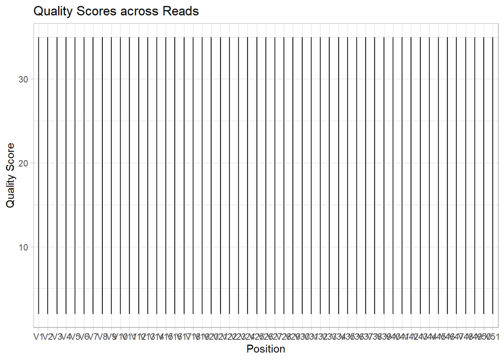

```r
ggplot(melted_df, aes(x = variable, y = value)) + geom_line() +
  labs(title = "Quality Scores across Reads", x = "Position", y = "Quality Score") + theme_light()
```

### 1. D. Trimming and Filtering Reads

Trimming involves removing low-quality bases from the ends of reads and filtering out reads that do not meet certain quality thresholds. The “cutadapt” tool or R packages like “Biostrings” or “DADA2” can be used for this purpose.

#### 1. D. I. Using DADA2 for trimming

```r
# Install DADA2 package
# BiocManager::install("dada2", version = "3.22")

# Load DADA2 package
library(dada2)
# Specify the path to your FASTQ files
path_in <- "D:/Ajay Files/R Programming for Bioinformatics/Chapter 6/Input file/"
path_out <- "D:/Ajay Files/R Programming for Bioinformatics/Chapter 6/Output file/"

fns_in <- list.files(path_in, pattern = "*fastq", full.names = TRUE)
fns_out <- list.files(path_out, pattern = "*fastq", full.names = TRUE)

# Run DADA2 to filter and trim reads
output_file = filterAndTrim(fwd = fns_in, filt = fns_out, truncLen = 40, maxEE = 2, truncQ = 2, compress = FALSE)
output_file
```

```
##                  reads.in reads.out
## wu_0_A_wgs.fastq   147354    111852
```

```r
# Runs DADA2 to filter and trim reads on "paired end reads
# output_file = filterAndTrim(fwd = fns_in, filt = fns_out, truncLen = c(200, 200), maxEE = c(2,2), truncQ = 2, compress = FALSE)
```

### 1. E. Aligning Reads to a Reference Genome

Once the reads are prep-proccessed, aligning them to a reference geneome is the subsequent step. R provides tools to interface with alignment software like “Bowtie” or “STAR”. The “Rsamtools” package can handle the aligned BAM files.

#### 1. E. I. ReadingAligned BAM files

```r
# Load "Rsamtools" package
library(Rsamtools)

# Load BAM file
bam_file <- "D:/Ajay Files/R Programming for Bioinformatics/Chapter 6/athal_wu_0_A.sam.bam"

# Load Index file (given without the "bai" file extension)
bam_index <- "D:/Ajay Files/R Programming for Bioinformatics/Chapter 6/athal_wu_0_A.sorted.bam"

# Get a summary of the aligned data
aln_data <- scanBam(bam_file, index = bam_index)
summary(aln_data)
```

```
##      Length Class  Mode
## [1,] 13     -none- list
```

```r
# Re-assign aligned data to the index containing the headings under which data is stored
aln_data <- aln_data[[1]]

# list the headings of the BAM aligned file
names(aln_data)
```

```
##  [1] "qname"  "flag"   "rname"  "strand" "pos"    "qwidth" "mapq"   "cigar"
##  [9] "mrnm"   "mpos"   "isize"  "seq"    "qual"
```

```r
# Use "lapply" function to list the 1st observation under each heading
lapply(aln_data, function(xx) xx[1])
```

```
## $qname
## [1] "GAII05_0002:1:113:7822:3886#0"
##
## $flag
## [1] 1187
##
## $rname
## [1] Chr3
## Levels: Chr1 Chr2 Chr3 Chr4 Chr5 chloroplast mitochondria
##
## $strand
## [1] +
## Levels: + - *
##
## $pos
## [1] 11699950
##
## $qwidth
## [1] 51
##
## $mapq
## [1] 60
##
## $cigar
## [1] "51M"
##
## $mrnm
## [1] Chr3
## Levels: Chr1 Chr2 Chr3 Chr4 Chr5 chloroplast mitochondria
##
## $mpos
## [1] 11700332
##
## $isize
## [1] 433
##
## $seq
## DNAStringSet object of length 1:
##     width seq
## [1]    51 AAAAAAAATGTAAAACTGCTAAATCTCTCCTCTCTAAAGAACTCGTCCCCG
##
## $qual
## PhredQuality object of length 1:
##     width seq
## [1]    51 CCCCCCBBBCCCCCCCCCCCCCCCCCCCCCCCCCCCBAAB??@ACBBCCCD
```

```r
# Summary of the contents of the "BAM" file
quickBamFlagSummary(bam_file)
```

```
##                                 group |    nb of |    nb of | mean / max
##                                    of |  records |   unique | records per
##                               records | in group |   QNAMEs | unique QNAME
## All records........................ A |   221372 |   147354 |  1.5 / 2
##   o template has single segment.... S |    65521 |    65521 |    1 / 1
##   o template has multiple segments. M |   155851 |    81833 |  1.9 / 2
##       - first segment.............. F |    77895 |    77895 |    1 / 1
##       - last segment............... L |    77956 |    77956 |    1 / 1
##       - other segment.............. O |        0 |        0 |   NA / NA
##
## Note that (S, M) is a partitioning of A, and (F, L, O) is a partitioning of M.
## Indentation reflects this.
##
## Details for group A:
##   o record is mapped.............. A1 |   218469 |   147354 | 1.48 / 2
##       - primary alignment......... A2 |   218469 |   147354 | 1.48 / 2
##       - secondary alignment....... A3 |        0 |        0 |   NA / NA
##   o record is unmapped............ A4 |     2903 |     2903 |    1 / 1
##
## Details for group S:
##   o record is mapped.............. S1 |    65521 |    65521 |    1 / 1
##       - primary alignment......... S2 |    65521 |    65521 |    1 / 1
##       - secondary alignment....... S3 |        0 |        0 |   NA / NA
##   o record is unmapped............ S4 |        0 |        0 |   NA / NA
##
## Details for group M:
##   o record is mapped.............. M1 |   152948 |    81833 | 1.87 / 2
##       - primary alignment......... M2 |   152948 |    81833 | 1.87 / 2
##       - secondary alignment....... M3 |        0 |        0 |   NA / NA
##   o record is unmapped............ M4 |     2903 |     2903 |    1 / 1
##
## Details for group F:
##   o record is mapped.............. F1 |    76681 |    76681 |    1 / 1
##       - primary alignment......... F2 |    76681 |    76681 |    1 / 1
##       - secondary alignment....... F3 |        0 |        0 |   NA / NA
##   o record is unmapped............ F4 |     1214 |     1214 |    1 / 1
##
## Details for group L:
##   o record is mapped.............. L1 |    76267 |    76267 |    1 / 1
##       - primary alignment......... L2 |    76267 |    76267 |    1 / 1
##       - secondary alignment....... L3 |        0 |        0 |   NA / NA
##   o record is unmapped............ L4 |     1689 |     1689 |    1 / 1
```

```r
# Setting up a bamview with a single file in it
bamView <- BamViews(bam_file)
bamView
```

```
## BamViews dim: 0 ranges x 1 samples
## names: athal_wu_0_A.sam.bam
## detail: use bamPaths(), bamSamples(), bamRanges(), ...
```

```r
# Reading in data with SCANBAM
aln_data <- scanBam(bamView)

# Gives the Outer
names(aln_data)
```

```
## [1] "athal_wu_0_A.sam.bam"
```

```r
# Gives a list (first level)
names(aln_data[[1]])
```

[output not shown]

```r
# Gives a list (second level), content
names(aln_data[[1]][[1]])
```

```
##  [1] "qname"  "flag"   "rname"  "strand" "pos"    "qwidth" "mapq"   "cigar"
##  [9] "mrnm"   "mpos"   "isize"  "seq"    "qual"
```

### 1. G. Generating Count Data

After alignment, the next step is to generate a count matrix, which contains the number of reads mapping to each feature, usually genes. The “Genomic Ranges” package, along with the “DESeq2”, allows for effective handling of this step.

#### 1. G. I. Counting Reads

```r
# Load "Biobase" library
library(Biobase)

# Load in data from a connection
con =url("http://bowtie-bio.sourceforge.net/recount/ExpressionSets/bottomly_eset.RData")
load(file=con)
close(con)
ls()
```

```
##  [1] "aln_data"       "bam_file"       "bam_index"      "bamView"
##  [5] "bottomly.eset"  "con"            "fastq_data"     "fastq_file"
##  [9] "fns_in"         "fns_out"        "melted_df"      "output_file"
## [13] "path_in"        "path_out"       "quality_df"     "quality_scores"
```

```r
bot = bottomly.eset
bot
```

```
## ExpressionSet (storageMode: lockedEnvironment)
## assayData: 36536 features, 21 samples
##   element names: exprs
## protocolData: none
## phenoData
##   sampleNames: SRX033480 SRX033488 ... SRX033494 (21 total)
##   varLabels: sample.id num.tech.reps ... lane.number (5 total)
##   varMetadata: labelDescription
## featureData
##   featureNames: ENSMUSG00000000001 ENSMUSG00000000003 ...
##     ENSMUSG00000090268 (36536 total)
##   fvarLabels: gene
##   fvarMetadata: labelDescription
## experimentData: use 'experimentData(object)'
## Annotation:
```

```r
pdata_bot=pData(bot)
head(pdata_bot)
```

```
##           sample.id num.tech.reps   strain experiment.number lane.number
## SRX033480 SRX033480             1 C57BL/6J                 6           1
## SRX033488 SRX033488             1 C57BL/6J                 7           1
## SRX033481 SRX033481             1 C57BL/6J                 6           2
## SRX033489 SRX033489             1 C57BL/6J                 7           2
## SRX033482 SRX033482             1 C57BL/6J                 6           3
## SRX033490 SRX033490             1 C57BL/6J                 7           3
```

```r
fdata_bot = featureData(bot)
head(fdata_bot)
```

```
## An object of class 'AnnotatedDataFrame'
##   featureNames: ENSMUSG00000000001 ENSMUSG00000000003 ...
##     ENSMUSG00000000049 (6 total)
##   varLabels: gene
##   varMetadata: labelDescription
```

```r
edata = exprs(bot)
head(edata, n=1)
```

```
##                    SRX033480 SRX033488 SRX033481 SRX033489 SRX033482 SRX033490
## ENSMUSG00000000001       369       744       287       769       348       803
##                    SRX033483 SRX033476 SRX033478 SRX033479 SRX033472 SRX033473
## ENSMUSG00000000001       433       469       585       321       301       461
##                    SRX033474 SRX033475 SRX033491 SRX033484 SRX033492 SRX033485
## ENSMUSG00000000001       309       374       781       555       820       294
##                    SRX033493 SRX033486 SRX033494
## ENSMUSG00000000001       758       419       857
```

```r
# Load "DESeq2" library
library(DESeq2)

# Create a "DESeq2" data set
count_data <- DESeqDataSetFromMatrix(countData = edata, pdata_bot, ~strain)
```

```
##   Note: levels of factors in the design contain characters other than
##   letters, numbers, '_' and '.'. It is recommended (but not required) to use
##   only letters, numbers, and delimiters '_' or '.', as these are safe characters
##   for column names in R. [This is a message, not a warning or an error]
```

```r
count_data
```

```
## class: DESeqDataSet
## dim: 36536 21
## metadata(1): version
## assays(1): counts
## rownames(36536): ENSMUSG00000000001 ENSMUSG00000000003 ...
##   ENSMUSG00000090267 ENSMUSG00000090268
## rowData names(0):
## colnames(21): SRX033480 SRX033488 ... SRX033486 SRX033494
## colData names(5): sample.id num.tech.reps strain experiment.number
##   lane.number
```

```r
# Pre-filtering low-count genes
count_data <- count_data[rowSums(counts(count_data))>1,]
count_data
```

```
## class: DESeqDataSet
## dim: 13356 21
## metadata(1): version
## assays(1): counts
## rownames(13356): ENSMUSG00000000001 ENSMUSG00000000028 ...
##   ENSMUSG00000090264 ENSMUSG00000090267
## rowData names(0):
## colnames(21): SRX033480 SRX033488 ... SRX033486 SRX033494
## colData names(5): sample.id num.tech.reps strain experiment.number
##   lane.number
```

Mastery of these techniques not only improves the quality of your analyses but is also fundamental to the reproducibility and reliability of your results. In the next chapter, we will dive deeper into statistical analysis and visualization techniques applicable to the pre-processing outcomes discussed in this chapter.

## 2. Quality Control and Pre-processing of FASTQ files

The FASTQ format, commonly used to store sequencing data, encapsulates both the sequence reads and their corresponding quality scores. Quality control and pre- processing of these FASTQ files are essential steps to ensure the reliability and accuracy of downstream analyses. This chapter presents a systemic approach to performing quality control and pre-processing of FASTQ files using R, a language widely adopted in statistical computing and bioinformatics.

### 2. A. Understanding the FASTQ Format.

Before delving into quality control, it’s essential to understand the structure of FASTQ files. Atypical FASTQ file consists of four lines per sequence:

- **Sequence Identifier**: A unique identifier for the sequence, starting with “@”.
- **Sequence**: The nucleotide sequence itself.
- **Optional Identifier**: Starts with a “+” and can be followed by the same identifier or left blank.
- **Quality Scores**: Encoded in ASCII characters that represent the quality of each nucleotide in the sequence.

This structure is vital for further processing, as it dictates how we will parse the data to perform quality control.

### 2. B. Importance of Quality Control

Quality control is imperative in sequencing data due to potential issues such as:

- **Low-quality reads**: that can introduce errors in downstream analyses
- **Contaminated sequences**: that may misrepresent biological insights
- **Batch effect**: from sequencing runs that need to be corrected or acknowledged

By conducting quality control, we can filter out unreliable sequences, ensuring a cohort of high-quality data that reflects true biological signals.

### 2. C. Tools for Quality Control in R.

- **Short Read**: Offers functionalities for reading, quality assessment, and manipulation of FASTQ files.
- **Biostrings**: Provides tools for efficient string representation and manipulation relevant to biological sequences.

To get started, make sure to install the required packages if they are not already installed:

#### 2. C. I. Install Packages

```r
# Install packages
# if(!requireNamespace("BiocManager", quietly = TRUE))
#    install.packages("BiocManager")

# BiocManager::install(c("ShortRead", "Biostrings"),
# type = "source", force = TRUE)
```

### 2. D. Reading FASTQ Files

Using the “Short Read” package, we can read FASTQ files into R. The “readFastq” function is particularly useful:

```r
# Load "Short Read" library
library(ShortRead)

# Replace "path/to/your/file.fastq" with the actual path to your FASTQ file
fastq_file <- readFastq("D:/Ajay Files/R Programming for Bioinformatics/Chapter 6/wu_0_A_wgs.fastq")

# Print Fastq file
print(fastq_file)
```

```
## class: ShortReadQ
## length: 147354 reads; width: 36..51 cycles
```

```r
# Display individual sequencing reads
fastq_file@sread
```

```
## DNAStringSet object of length 147354:
##          width seq
##      [1]    51 TACAAGGATTTTTAAAAGGGGTTTAAAAACATTAATAATGATTTTACAAGG
##      [2]    36 GAAACATTGTGTCTCAATATCCAAAAGTGCTTGAAA
##      [3]    51 AAAGTTTATGGTGAAAATTTCAGGAGCAAAAAGTATAGGGGGGAAAGCTGA
##      [4]    51 ATCCAAAAAAAAAAGAAAATGCCAAACTATATCAACGTTAGACAATAGCGC
##      [5]    36 GGGCGGTTTTCAGTTAAGTCAGCCTATGCTTTACTA
##      ...   ... ...
## [147350]    50 GTAATAGCTGGTGTAAGCTCGGCTTGTACGATGCTGATTTCGGATGGGGA
## [147351]    50 AAACTCAATCAAGTAAAGAAGTACAGAACAAAAAATGCGCTAGCATTTAA
## [147352]    50 AGGGAGCATGCATCTCCGAGAGTCAGCCATGGTATCTCCATTTCGTATGC
## [147353]    50 AGTTTCAAAATTTTATTATTATTTACATAAAAAATAACGATACATATAAA
## [147354]    50 TGTGCTAATGGAATATTCGGATAATTTGAAATGTCTTTATTATAACACAA
```

This will load the FASTQ file into R, allowing you to examine the content and access the quality scores associated with each base in the sequences.

### 2. E. Performing Quality Control

#### 2. E. I. Visualizing Quality Scores

```r
# Load "ggplot2"  and "DADA2" library
library(ggplot2)
library(dada2)

# Extract quality scores
quality_scores <- quality(fastq_file)
quality_scores
```

```
## class: FastqQuality
## quality:
## BStringSet object of length 147354:
##          width seq
##      [1]    51 CCCCCCCCCCCCCCCCCCCCCCCCCCCCCCBBCCCCCCCCCCCCCCCCCCC
##      [2]    36 3;@=?=48>>>?:7?BB>A:A:A@BB=:AB@ABBBB
##      [3]    51 CCCCCCCCCCCCCCCCCCCCCCCCCCCCCCCCCDCCCCCCCCCCCCCCCCC
##      [4]    51 C;C>BBBBBBBBBCCCCCCCCCCCCCCCCCCCCCCCCCCCCCCCCCCCCCC
##      [5]    36 BA?6=@==>?=BB@>AB@<4?A;7=B>B>;??>@>@
##      ...   ... ...
## [147350]    50 CCCCCCCCCCCCCCCCCCCCCCCCCCCCCCCCCCCCCCCCCCCCCCCCCC
## [147351]    50 CCCCCCCCCCCCCCCCCCCCCCCCCCCCCCCCCCCCCCCCCCCCCCCCCC
## [147352]    50 CCCCCCCCCCCCCCCCCCCCCCCCCCCCCCCCCCCCCCCCCCCCCCCCCC
## [147353]    50 CCCCCCCCCCCCCCCCCCCCCCCCCCCCCCCCCCCCCCCCCCCCCCCCCC
## [147354]    50 CCCCCCCCCCCCCCCCCCCCCCCCCCCCCCCCCCCCCCCCCCCCCCCCCC
```

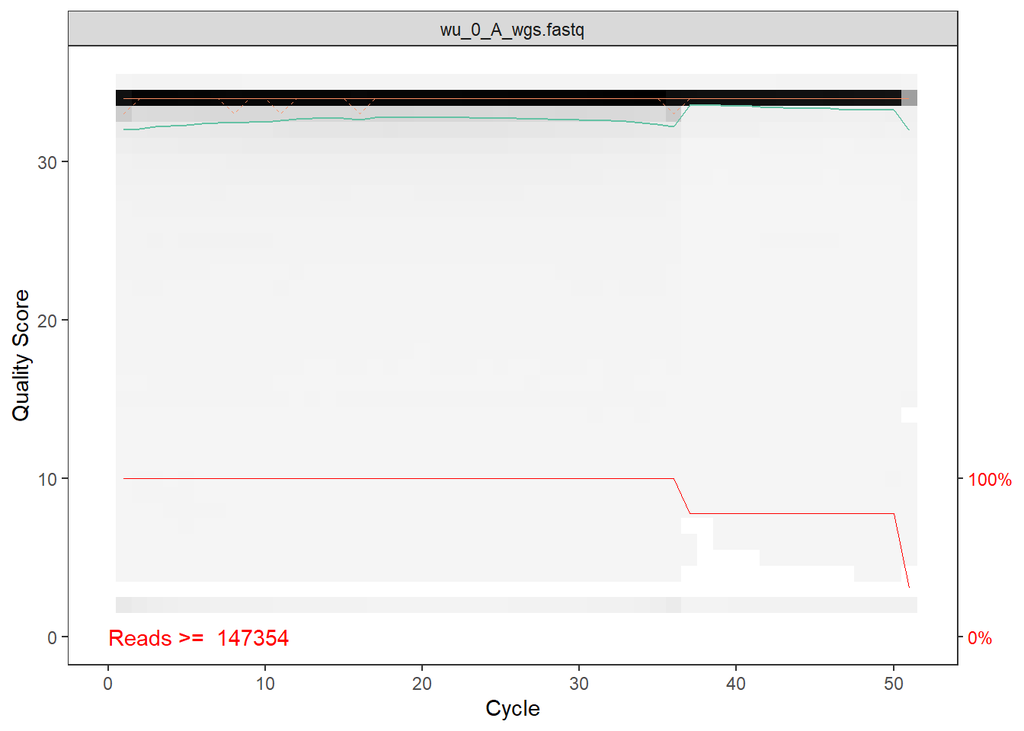

```r
# Plot quality scores
fastq_filepath <- "D:/Ajay Files/R Programming for Bioinformatics/Chapter 6/wu_0_A_wgs.fastq"
plotQualityProfile(fastq_filepath, n = 147354)
```

This visualization helps in identifying systematic issues such as drops in quality across sequences, which may suggest the need for further filtering

#### 2. E. II. Filtering Low-Quality Reads

Based on visualizations, one common method for filtering is to remove reads with average quality score below a specified threshold. We can calculate the average quality score for each read and filter accordingly.

```r
# Set a quality threshold
quality_threshold <- 20 # Example threshold

# Calculate average quality scores and filter
# filtered_reads <- fastq_file[width(quality_scores) == 0 | rowMeans(as(quality_scores, "matrix")) >= quality_threshold]

# filtered_reads <- fastq_file@quality@quality@ranges@width[(quality_scores) == 0 |rowMeans(as(quality_scores), "matrix") >= quality_threshold]

# print(filtered_reads)
```

#### 2. E. II. Filtering Low-Quality Reads - adjusted code

Above code doesn’t work code below works because the fastq data is an S4 Class. This S4 class needs to be coerced into a numeric matrix, before average quality scores can be calculated using the row means function. Then you use the average quality score for each read and compare it to the required quality threshold of 20 and use indexing to select reads that are >= the quality score of 20

```r
# Filtering reads with quality scores below a threshold Coerce to a numeric matrix
# Rows = reads; Columns = sequencing cycles/positions
qual_mat <- as(quality(fastq_data), "matrix")
head(qual_mat, n = 2)
```

```
##      [,1] [,2] [,3] [,4] [,5] [,6] [,7] [,8] [,9] [,10] [,11] [,12] [,13] [,14]
## [1,]   34   34   34   34   34   34   34   34   34    34    34    34    34    34
## [2,]   18   26   31   28   30   28   19   23   29    29    29    30    25    22
##      [,15] [,16] [,17] [,18] [,19] [,20] [,21] [,22] [,23] [,24] [,25] [,26]
## [1,]    34    34    34    34    34    34    34    34    34    34    34    34
## [2,]    30    33    33    29    32    25    32    25    32    31    33    33
##      [,27] [,28] [,29] [,30] [,31] [,32] [,33] [,34] [,35] [,36] [,37] [,38]
## [1,]    34    34    34    34    33    33    34    34    34    34    34    34
## [2,]    28    25    32    33    31    32    33    33    33    33    NA    NA
##      [,39] [,40] [,41] [,42] [,43] [,44] [,45] [,46] [,47] [,48] [,49] [,50]
## [1,]    34    34    34    34    34    34    34    34    34    34    34    34
## [2,]    NA    NA    NA    NA    NA    NA    NA    NA    NA    NA    NA    NA
##      [,51]
## [1,]    34
## [2,]    NA
```

```r
# Calculate a metric (e.g., average quality score per read)
# Use na.rm = TRUE if reads have unequal lengths
avg_quality <- rowMeans(qual_mat, na.rm = TRUE)
head(avg_quality)
```

```
## [1] 33.96078 29.11111 34.01961 33.56863 29.27778 33.96078
```

```r
# Filter the original S4 object
filtered_reads <- fastq_data[avg_quality >= 20]
head(filtered_reads)
```

```
## class: ShortReadQ
## length: 6 reads; width: 36 51 cycles
```

```r
# Summary of filtered reads
summary(filtered_reads)
```

```
##     Length      Class       Mode
##     145740 ShortReadQ         S4
```

This code snippet demonstrates how to retain only those reads that exceed the designated quality threshold, improving the overall quality of out data set.

### 2. F. Trimming Sequences

```r
# Trimming based on a quality score threshold.
print(fastq_file)
```

```
## class: ShortReadQ
## length: 147354 reads; width: 36..51 cycles
```

```r
trimmed_reads <- trimTails(fastq_file, k = 1, a = 5)
print(trimmed_reads)
```

```
## class: ShortReadQ
## length: 140393 reads; width: 1..51 cycles
```

- **(Quality Score = 20) == (ASCII score = 53) == (ASCII character = 5)**
- **k =** integer(1) describing the number of failing letters required to trigger trimming.
- **a =** ASCII character at or below which a nucleotide is marked as failing.

### 2. G. Outputting Processed FASTQ Files

After quality control and pre-processing, it is often necessary to write the cleaned reads back to a new FASTQ file for downstream analyses:

```r
writeFastq(trimmed_reads, "D:/Ajay Files/R Programming for Bioinformatics/Chapter 6/cleaned_file.fastq", mode = "a")
```

This command saves the processed FASTQ file, ensuring that it can be utilized in subsequent analyses or workflows.

Quality control and pre-processing of FASTQ files are critical for reliable bioinformatics analyses. In this chapter, we presented a comprehensive overview of how to perform these tasks using R, from visualizing quality scores to filtering reads and trimming sequences. By leveraging the tools available in R, researchers can ensure that their sequencing data is of high quality, thus enhancing the validity of their findings.

## 3. Using Short Read and Rsamtools for Sequence Data Management

This chapter focuses on two prominent R packages: **Short Read** and **Rsamtools**. Together, these packages facilitate efficient management, manipulation, and analysis of sequence data, particularly in the context of next-generation sequencing (NGS).

### 3. A. Overview of Short Read and Rsamtools

- **Short Read** is an R package designed to facilitate the handling of short sequence reads, including the reading, writing and processing of FASTQ files, which store nucleotide sequences along with their quality scores. It provides user-friendly functions to manipulate sequence data and assess the quality of reads.
- **Rsamtools**, on the other hand, offers tools specifically for manipulating high-throughput sequencing data in the BAM (Binary Alignment/Map) format, which is the compressed binary version of SAM format. Rsamtools allows users to read, write, and index BAM files, making it crucial for working with aligned sequence data.

By integrating these two packages, researchers can streamline the workflow from raw sequence data to processed and analyzable formats, enabling downstream analysis such as variant calling, gene expression studies, and more.

### 3. B. Installing the Packages

To begin using Short Read and Rsamtools, you first need to install them from Bioconductor, a popular repository for bioinformatics packages in R. If you haven’t already set up Bioconductor, you can do so with the following commands.

#### 3. B. I. Install packages

```r
# if(!requireNamespace("BiocManager", quietly = TRUE))
#    install.packages("BiocManager")

# BiocManager::install(c("ShortRead", "Biostrings"),
# type = "source", force = TRUE)
```

#### 3. B. II. Loading libraries

Once the packages are installed, you can load them into your R session:

```r
library(ShortRead)
library(Rsamtools)
```

### 3. C. Importing Sequencing Data

#### 3. C. I. Importing FASTQ Files with Short Read

The primary function for reading FASTQ files in ShortRead is “readFastq()”. This function loads sequence data into R as a “Short Read Q” object. Below is an example of how to import a FASTQ file:

```r
# Specify the path to your FASTQ file
fastq_file <- "D:/Ajay Files/R Programming for Bioinformatics/Chapter 6/wu_0_A_wgs.fastq"

# Read the FASTQ file
fastq_data <- readFastq(fastq_file)

# Display a summary of the imported data
summary(fastq_data)
```

```
##     Length      Class       Mode
##     147354 ShortReadQ         S4
```

#### 3. C. II. Inspecting Quality Scores

After importing sequencing data. it’s crucial to inspect the quality of the reads. Short Read provides various methods to visualize and check the quality scores.

```r
# Extract quality scores
quality_scores <- quality(fastq_data)
quality_scores
```

```
## class: FastqQuality
## quality:
## BStringSet object of length 147354:
##          width seq
##      [1]    51 CCCCCCCCCCCCCCCCCCCCCCCCCCCCCCBBCCCCCCCCCCCCCCCCCCC
##      [2]    36 3;@=?=48>>>?:7?BB>A:A:A@BB=:AB@ABBBB
##      [3]    51 CCCCCCCCCCCCCCCCCCCCCCCCCCCCCCCCCDCCCCCCCCCCCCCCCCC
##      [4]    51 C;C>BBBBBBBBBCCCCCCCCCCCCCCCCCCCCCCCCCCCCCCCCCCCCCC
##      [5]    36 BA?6=@==>?=BB@>AB@<4?A;7=B>B>;??>@>@
##      ...   ... ...
## [147350]    50 CCCCCCCCCCCCCCCCCCCCCCCCCCCCCCCCCCCCCCCCCCCCCCCCCC
## [147351]    50 CCCCCCCCCCCCCCCCCCCCCCCCCCCCCCCCCCCCCCCCCCCCCCCCCC
## [147352]    50 CCCCCCCCCCCCCCCCCCCCCCCCCCCCCCCCCCCCCCCCCCCCCCCCCC
## [147353]    50 CCCCCCCCCCCCCCCCCCCCCCCCCCCCCCCCCCCCCCCCCCCCCCCCCC
## [147354]    50 CCCCCCCCCCCCCCCCCCCCCCCCCCCCCCCCCCCCCCCCCCCCCCCCCC
```

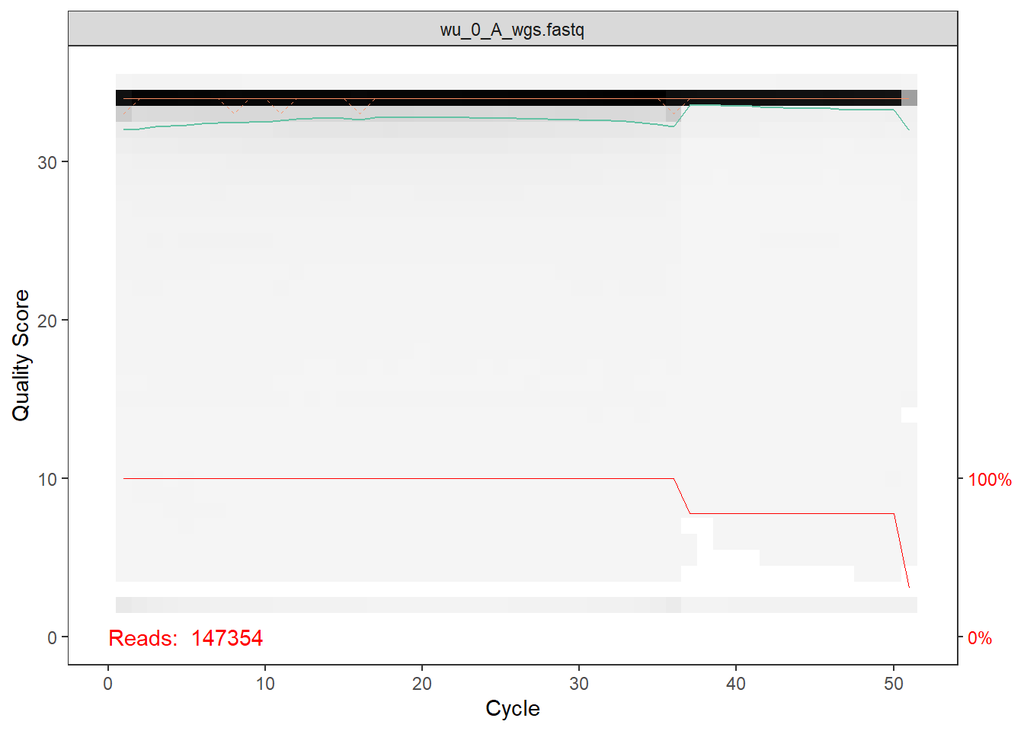

```r
# Plot quality scores
plotQualityProfile(fastq_file)
```

This will generate a visual representation of the quality scores across the length of the reads, allowing you to assess whether your data meets quality thresholds for further analysis.

#### 3. C. III. Importing BAM Files with Rsamtools

For working with BAM files, Rsamtools provides the “BamFile()” function to create a BAM file connection. Reading the data can be done using the “readGAlignments()” function. Here’s how to do it:

```r
# Specify the path to your BAM file
bam_file <- "D:/Ajay Files/R Programming for Bioinformatics/Chapter 6/athal_wu_0_A.sam.bam"

# Create a BAM file connection
bam_data <- BamFile(bam_file)
bam_data
```

```
## class: BamFile
## path: D:/Ajay Files/R Programming for Bioinformatics/Cha.../athal_wu_0_A.sam.bam
## index: D:/Ajay Files/R Programming for Bioinformatic.../athal_wu_0_A.sam.bam.bai
## isOpen: FALSE
## yieldSize: NA
## obeyQname: FALSE
## asMates: FALSE
## qnamePrefixEnd: NA
## qnameSuffixStart: NA
```

```r
# Read the alignments
alignments <- readGAlignments(bam_data)
alignments
```

```
## GAlignments object with 218469 alignments and 0 metadata columns:
##            seqnames strand       cigar    qwidth     start       end     width
##               <Rle>  <Rle> <character> <integer> <integer> <integer> <integer>
##        [1]     Chr3      +         51M        51  11699950  11700000        51
##        [2]     Chr3      +         51M        51  11699950  11700000        51
##        [3]     Chr3      -         51M        51  11699952  11700002        51
##        [4]     Chr3      +         51M        51  11699953  11700003        51
##        [5]     Chr3      -         51M        51  11699968  11700018        51
##        ...      ...    ...         ...       ...       ...       ...       ...
##   [218465]     Chr3      -         51M        51  11999987  12000037        51
##   [218466]     Chr3      +         51M        51  11999990  12000040        51
##   [218467]     Chr3      +         36M        36  11999996  12000031        36
##   [218468]     Chr3      -         36M        36  11999997  12000032        36
##   [218469]     Chr3      +         36M        36  12000000  12000035        36
##                njunc
##            <integer>
##        [1]         0
##        [2]         0
##        [3]         0
##        [4]         0
##        [5]         0
##        ...       ...
##   [218465]         0
##   [218466]         0
##   [218467]         0
##   [218468]         0
##   [218469]         0
##   -------
##   seqinfo: 7 sequences from an unspecified genome
```

```r
# Display a summary of the alignments
summary(alignments)
```

```
## [1] "GAlignments object of length 218469 with 0 metadata columns"
```

### 3. D. Data Manipulation

#### 3. D. I. Filtering Sequences

Often, you may need to filter sequences based on quality scores or other criteria. For instance, filtering low-quality reads from the FASTQ data can be performed as follows:

```r
# Filtering reads with quality scores below a threshold Coerce to a numeric matrix
# Rows = reads; Columns = sequencing cycles/positions
qual_mat <- as(quality(fastq_data), "matrix")
head(qual_mat, n = 2)
```

```
##      [,1] [,2] [,3] [,4] [,5] [,6] [,7] [,8] [,9] [,10] [,11] [,12] [,13] [,14]
## [1,]   34   34   34   34   34   34   34   34   34    34    34    34    34    34
## [2,]   18   26   31   28   30   28   19   23   29    29    29    30    25    22
##      [,15] [,16] [,17] [,18] [,19] [,20] [,21] [,22] [,23] [,24] [,25] [,26]
## [1,]    34    34    34    34    34    34    34    34    34    34    34    34
## [2,]    30    33    33    29    32    25    32    25    32    31    33    33
##      [,27] [,28] [,29] [,30] [,31] [,32] [,33] [,34] [,35] [,36] [,37] [,38]
## [1,]    34    34    34    34    33    33    34    34    34    34    34    34
## [2,]    28    25    32    33    31    32    33    33    33    33    NA    NA
##      [,39] [,40] [,41] [,42] [,43] [,44] [,45] [,46] [,47] [,48] [,49] [,50]
## [1,]    34    34    34    34    34    34    34    34    34    34    34    34
## [2,]    NA    NA    NA    NA    NA    NA    NA    NA    NA    NA    NA    NA
##      [,51]
## [1,]    34
## [2,]    NA
```

```r
# Calculate a metric (e.g., average quality score per read)
# Use na.rm = TRUE if reads have unequal lengths
avg_quality <- rowMeans(qual_mat, na.rm = TRUE)
head(avg_quality)
```

```
## [1] 33.96078 29.11111 34.01961 33.56863 29.27778 33.96078
```

```r
# Filter the original S4 object
filtered_reads <- fastq_data[avg_quality >= 20]
head(filtered_reads)
```

```
## class: ShortReadQ
## length: 6 reads; width: 36 51 cycles
```

```r
# Summary of filtered reads
summary(filtered_reads)
```

```
##     Length      Class       Mode
##     145740 ShortReadQ         S4
```

#### 3. D. II. Subsetting Alignments

For BAM files, you can subset alignments based on specified regions or specific criteria such as read names:

```r
# Subset alignments based on specific chromosomes or regions
chr3_alignments <- alignments[seqnames(alignments) == "Chr3"]
chr3_alignments
```

```
## GAlignments object with 218469 alignments and 0 metadata columns:
##            seqnames strand       cigar    qwidth     start       end     width
##               <Rle>  <Rle> <character> <integer> <integer> <integer> <integer>
##        [1]     Chr3      +         51M        51  11699950  11700000        51
##        [2]     Chr3      +         51M        51  11699950  11700000        51
##        [3]     Chr3      -         51M        51  11699952  11700002        51
##        [4]     Chr3      +         51M        51  11699953  11700003        51
##        [5]     Chr3      -         51M        51  11699968  11700018        51
##        ...      ...    ...         ...       ...       ...       ...       ...
##   [218465]     Chr3      -         51M        51  11999987  12000037        51
##   [218466]     Chr3      +         51M        51  11999990  12000040        51
##   [218467]     Chr3      +         36M        36  11999996  12000031        36
##   [218468]     Chr3      -         36M        36  11999997  12000032        36
##   [218469]     Chr3      +         36M        36  12000000  12000035        36
##                njunc
##            <integer>
##        [1]         0
##        [2]         0
##        [3]         0
##        [4]         0
##        [5]         0
##        ...       ...
##   [218465]         0
##   [218466]         0
##   [218467]         0
##   [218468]         0
##   [218469]         0
##   -------
##   seqinfo: 7 sequences from an unspecified genome
```

```r
# Display the number of alignments in Chromosome 3 (Chr3)
length(chr3_alignments)
```

```
## [1] 218469
```

### 3. E. Writing Sequence Data

After processing the sequence data, you may want to save your results. Short Read and Rsamtools allow you to write output in various formats.

#### 3. E. I. Writing FASTQ Files

To write filtered or modified reads back to a FASTQ file using Short Read, you can utilize the “write Fastq()” function:

Write filtered reads to a new FASTQ file.

```r
# Create a new FASTQ file
file_path = "D:/Ajay Files/R Programming for Bioinformatics/Chapter 6/filtered_sequences.fastq"

# Write filtered reads to a FASTQ file
writeFastq(filtered_reads, file_path, mode = "a")
```

#### 3. E. II. Writing BAM Files

```r
# Install "rtracklayer"
BiocManager::install("rtracklayer")
# Rsamtools does not have "writeGAlignments()" function so load these packages below
library(GenomicAlignments)
library(rtracklayer)

# Create a new BAM file
output_bam <- "D:/Ajay Files/R Programming for Bioinformatics/Chapter 6/filtered_sequences.bam"

# Write alignments to BAM file
export(chr3_alignments, output_bam, format = "BAM")
# writeGAlignments(chr3_alignments, output_bam)
# .libPaths()
```

From importing sequence files in FASTQ and BAM formats to filtering, manipulating and writing output files, these tools provide a robust framework for handling the complexities of high-throughput sequencing data. By leveraging the capabilities of these packages, researchers can streamline their workflows, enabling more efficient data analysis and interpretation in their biological studies.

```r
Sys.Date()
```

```
## [1] "2026-01-18"
```